# Financing the Air We Breathe: Climate vs. Non-Climate Aid and Local CO2 Emissions

Staggered Event-Study and Dose–Response Evidence from Global ADM2 Data

Authors

Pierre Beaucoral[^3]

Université Clermont Auvergne, CNRS, IRD, CERDI, pierre.beaucoral@uca.fr

Published

November 19, 2025

Abstract

# 1 Introduction

International and domestic climate finance increasingly flows through, or must be implemented by, sub-national governments. Cities and regions control large shares of infrastructure investment, land-use regulation, and service delivery. Yet credible evidence on who receives climate finance, at what cost, and with what effects remains fragmented across disciplines. This article organizes that evidence articulates a tractable conceptual framework, and maps it to empirical strategies suitable for causal evaluation.

# 2 Literature Review

The relationship between development, climate aid/finance, and CO2 emissions is complex. Climate finance and targeted aid can reduce CO2 emissions, but the effectiveness depends on the type of aid, governance, and the stage of economic development. Economic growth and financial development alone often increase emissions unless paired with green finance or strong environmental policies.

Climate finance, especially when directed toward mitigation, is associated with lower CO2 emissions, with stronger effects in countries with higher economic development and in small island states (C.-C. Lee et al. 2022; Khan, Ahmed, and Hull 2023). Green finance and green technology innovation consistently show significant negative impacts on CO2 emissions in both developed (G7, OECD) and emerging economies (BRICS) (Sharif et al. 2022; Saeed Meo and Karim 2022; Umar and Safi 2023; Sadiq et al. 2024). Climate aid for renewable energy has a slight but transitory effect on reducing CO2 emissions, with greater impact after a certain threshold. However, its effectiveness is limited if recipient countries prioritize economic over ecological efficiency (Kablan and Chouard 2022).

Regarding Official Development Assistance (ODA), it can directly and indirectly mitigate CO2 emissions, but the effect is stronger in middle-income countries and when governance is robust. In low-income countries, the impact is limited (Barkat, Alsamara, and Mimouni 2024; S. K. Lee et al. 2020; Farooq 2021; Mahalik et al. 2021). However, aid directed toward fossil fuel development increases CO2 emissions, especially in countries with less environmental regime integration (K. E. Henderson and Sommer 2022; K. E. Henderson 2019). Strong governance and environmental policies enhance the effectiveness of aid and finance in reducing emissions (Barkat, Alsamara, and Mimouni 2024; Farooq 2021; K. E. Henderson 2019).

Recent research provides clear evidence that green finance and climate aid can significantly reduce CO2 emissions at the subnational (regional or city) level, but the effectiveness varies by region, policy design, and local economic structure.

Studies using data from hundreds of Chinese cities and provinces show that green finance policies and instruments (such as green loans and subsidies) have a significant negative effect on CO2 emissions intensity at the subnational level. The effect is stronger in eastern and non-resource-based cities, while central and western or resource-dependent regions see weaker impacts (Y. Sun, Bao, and Taghizadeh-Hesary 2023; F. Wang, Cai, and Elahi 2021; Zhao et al. 2024; H. Li et al. 2025). Uniform national policies may be less effective than regionally tailored approaches. Incentive-based policies work better in developed eastern provinces, while a mix of supportive and pressure policies (like carbon taxes) are needed in less developed central regions (Y. Sun, Bao, and Taghizadeh-Hesary 2023; H. Li et al. 2025). Green finance reduces emissions by supporting green technology innovation, upgrading industrial structure, and promoting renewable energy adoption. Debt-based green finance instruments are more effective than equity-based ones in reducing emissions at the city level (F. Wang, Cai, and Elahi 2021; Zhao et al. 2024) . At the micro level, green finance helps firms reduce emissions through lower financing costs, technological innovation, and external supervision. However, emission reduction is less pronounced in heavy-polluting and resource-based industries (Zhao et al. 2024).

Green finance projects, those specifically designed to support low-carbon, environmentally sustainable activities, consistently outperform traditional development finance projects in reducing CO2 emissions at the subnational (regional or city) level. Green finance significantly reduces local and neighboring CO2 emissions, with a 1% increase in green financial development linked to a 3% decrease in regional emissions (J. Sun et al. 2022; Chen and Chen 2021; Su, Qiao, and Xu 2024). The effect is strongest in economically advanced or eastern regions and in non-resource-based cities, where financial markets and green policy implementation are more mature (Chen and Chen 2021; Su, Qiao, and Xu 2024). Green finance also creates “ripple effects,” reducing emissions in adjacent areas by promoting green technology and industrial upgrades (J. Sun et al. 2022; Chen and Chen 2021; Su, Qiao, and Xu 2024).

General development finance (not specifically climate-related) can have mixed or even adverse effects on emissions. In some cases, it increases emissions by fueling economic growth and energy consumption, especially in less developed or resource-dependent regions (Chen and Chen 2021; Su, Qiao, and Xu 2024; L. Wang, Yang, and Cai 2024; Mumuni and Hamadjoda Lefe 2023) . The emission-reducing effect of traditional finance is weaker, and in some regions, it may actually exacerbate pollution unless paired with strong environmental regulations or targeted toward green sectors (Chen and Chen 2021; L. Wang, Yang, and Cai 2024). Traditional finance lacks these targeted mechanisms and may inadvertently support high-emission sectors (Chen and Chen 2021; L. Wang, Yang, and Cai 2024).

At the subnational level, green finance projects are significantly more effective than traditional development finance in reducing CO2 emissions, especially in regions with mature financial systems and strong policy support. Traditional finance may have limited or even negative environmental effects unless explicitly directed toward green objectives.

Taken together, the existing evidence shows that green‐oriented finance can curb CO2 emissions, especially where governance and market depth support absorption, yet most subnational findings are China-centric, many designs are correlational, and “climate” vs. “traditional” finance is often measured with coarse, donor-provided labels. Furthermore, most of previously cited sttudies are focused on green finance, not climate finance that is especially designed toward adaptation or mitigation purposes, whereas green finance is more widely “environment related”. This leaves four central gaps: (i) limited external validity at fine geographic scales, (ii) weak causal identification of dynamic, project-level effects and spillovers, (iii) insufficient separation of mechanisms (mitigation vs. adaptation) and measurement error in climate tagging, and (iv) limited insights looking especially at climate finance.

I leverage spatially explicit project data and a modern identification strategy to estimate the causal effect of climate finance on local pollution. This design combines (i) staggered adoption DiD (Callaway and Sant’Anna 2021) to identify average dynamic effects and (ii) dose–response analyses that compare dynamics across post-treatment exposure bins and via continuous doses at the ADM2–year level. This two-pronged approach distinguishes targeting from treatment intensity and is well-suited to the lumpy, time-varying nature of climate finance.

# 3 Data

I construct an ADM2–year panel by integrating two sources. First, I use the GODAD project database (Bomprezzi et al. 2024). In order to get know whether or not projects in this datset were climate related, I use ClimateFinanceBERT (Toetzke, Stünzi, and Egli 2022) to classify projects from GODAD into climate-relevant or not and for those that were climate relevant, into adaptation, mitigation or environment categories. It allows me to get a description-based estimation of overall climate finance. For financing, I prioritize disb_loc_evensplit and substitute comm_loc_evensplit when the former is unavailable. Second, I merge environmental outcomes from EDGAR, aggregated to the ADM2 level by area-weighted averaging.

For each category, the adoption year for ADM2 $j$ is defined as the first year with a strictly positive monetary amount:

$g_j \equiv \min\{t:\ \text{Amount}_{jt}>0\}.$

Post-treatment exposure is the cumulative amount from the adoption year to the end of the panel:

$\text{Exposure}_{j} \equiv \sum_{t \ge g_j} \text{Amount}_{jt}.$

I partition treated ADM2s into intensity bins given by the empirical quantiles of $\text{Exposure}_j$. For descriptive cross-country figures, country–year totals are computed directly from GODAD by aggregating project amounts to the country–year level.

For the outcome variable, I build a global ADM2–year panel of territorial CO₂ emissions by aggregating the EDGAR 0.1° “CO₂ TOTALS” rasters (2000–2022) to second-level administrative boundaries. ADM2 polygons are loaded from GADM, validated and harmonized (ISO3, ADM1/ADM2 names, stable GID), and re-projected to WGS84. For each year, I read the corresponding EDGAR raster (netCDF/GeoTIFF), ensure CRS consistency, and for efficiency, crop by country envelope before extracting area-weighted sums over each ADM2. The resulting tonnes are stored and cached. Note that these ADM2 values are *model-based allocations* of national/sector totals onto grid cells rather than native administrative measurements; precision is therefore higher where emissions come from mapped point sources (power/industry) and lower for diffuse sectors, and results can be sensitive to boundary definitions and small polygons, issues that are mitigated with exact area weighting and explicit versioning of both EDGAR and GADM.

# 4 Empirical Strategy

Let $Y_{jt}$ denote log pollution in ADM2 $j$ and year $t$. We estimate group-time average treatment effects using the **CS** estimator with not-yet-treated controls:

$ATT(g,e) = \mathbb{E}[Y_{jt}(1) - Y_{jt}(0) \mid g_j = g,, t-g = e],$

and aggregate to dynamic event-time profiles with simultaneous confidence bands. To study heterogeneity by dose, we compute post-treatment totals (commitments/disbursements) and re-estimate dynamics within dose bins. This recovers a policy-relevant “more money means larger effects?” gradient while preserving the staggered-adoption identification.

## 4.1 Sample description

Table 1: Panel overview (ADM2–year).

Panel overview (ADM2–year).

| Statistic | Value |
| --- | --- |
| Obs. (ADM2–year) | 878 669 |
| ADM2 units | 38 203 |
| Years | 23 |
| Year span | 2000–2022 |
| Ever treated ADM2 | 4 736 |
| Never treated ADM2 | 33 467 |
| Share treated by last year | 12.4% |

Treated = ADM2 with first positive climate amount (adaptation or mitigation). Share computed at the last year available.

One can observe from Table 1 that the panel is large and nearly balanced, 38,203 ADM2 units observed over 23 years (2000–2022) yielding 878,669 unit–years, so missingness is minimal and pre-trend and medium-run dynamics are feasible. Only 12.4% of ADM2s are ever treated by 2022 (4,736 units), which provides abundant never- or not-yet-treated controls well suited to modern staggered DiD designs, while warranting overlap diagnostics and, if necessary, reweighting or trimming to common support. Staggered adoption and the definition of treatment as the first positive climate amount naturally motivate dynamic event-study ATTs alongside dose–response analyses based on cumulative post-treatment exposure. For clarity, note that the reported “share treated by last year” is the fraction ever treated by the final year, not the fraction treated in that year. Given the sample size and number of treated clusters, average effects should be precisely estimated.

Table 2: Descriptive statistics for log CO$_2$ outcomes: overall and by treatment status.

Descriptive statistics for log CO$_2$ outcomes: overall and by treatment status.

| Group | N | Mean | Sd | P10.10% | P50.50% | P90.90% |
| --- | --- | --- | --- | --- | --- | --- |
| Overall | 878669.000 | 10.558 | 2.072 | 8.308 | 10.412 | 13.195 |
| Never treated | 769741.000 | 10.441 | 2.008 | 8.264 | 10.312 | 12.983 |
| Ever treated | 108928.000 | 11.386 | 2.312 | 8.744 | 11.148 | 14.511 |

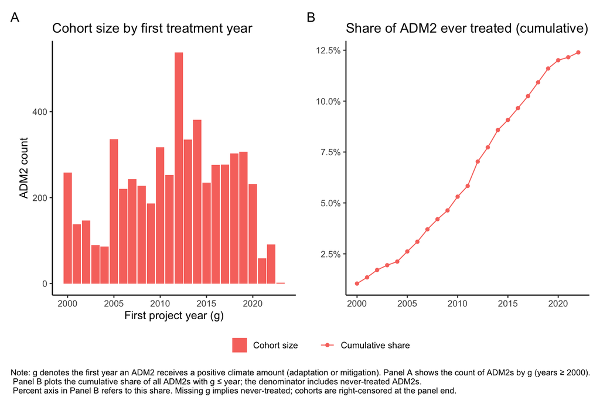

Figure 1: Adoption dynamics at ADM2 level: (A) cohort size by first treatment year; (B) cumulative share of ADM2 ever treated.

According to Figure 1, the adoption profile is clearly staggered and concentrated in the early-to-mid 2010s: Panel A shows modest early cohorts, a marked ramp-up around 2011–2016, and thinning cohorts thereafter (partly right-censoring near the panel end), while Panel B’s S-shaped curve plateaus at $≈12–13\%$ of ADM2s by 2022. Combined with earlier descriptives, treated ADM2s are systematically more CO₂-intensive, this pattern is consistent with selective rollout toward higher-emitting, more urban/industrial areas rather than random diffusion. Empirically, these features favor staggered event-study designs with rich fixed effects, but they also call for explicit pre-trend tests (anticipation and dose–response specifications using post-treatment exposure.

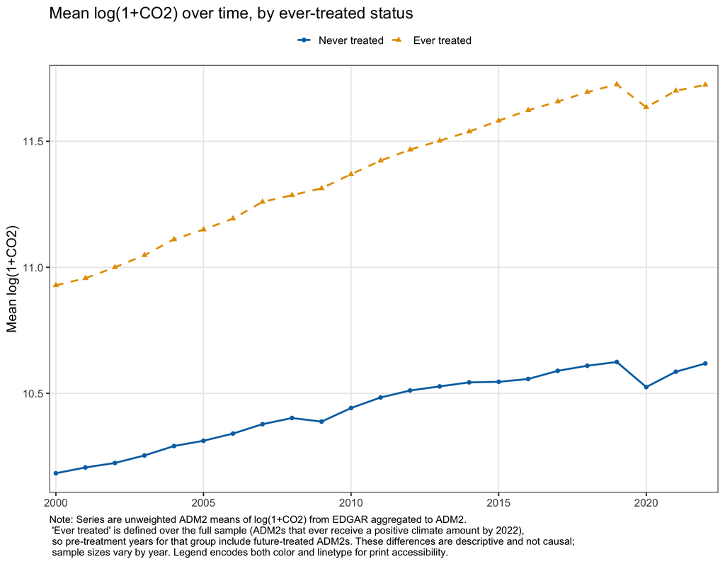

Figure 2: Unadjusted means of log(1+CO$_2$) by treatment status over time.

[figure not shown]

Figure 3: ADM2-level cumulative climate finance (USD, log₁₀ scale). Light grey = no projects.

Figure 3 shows a highly clustered footprint of climate-project exposure at the ADM2 level with a dense concentrations across Sub-Saharan Africa (Sahel, Great Lakes, coastal West Africa), South Asia (Indo-Gangetic plain and Himalayan foothills), and parts of Southeast Asia, with smaller pockets in the Andes and Central America; coverage is sparse in North Africa/Middle East and essentially absent in high-income countries (by design). This spatial pattern is consistent with targeting toward populous/urbanizing and vulnerable corridors.

# 5 Results

I identify dynamic treatment effects by comparing newly treated ADM2s to ADM2s that have not yet received a climate project in that event-time, which preserves credible counterfactuals under staggered adoption. With only 12.4% of ADM2s ever treated by 2022, the panel supplies abundant not-yet-treated controls for each cohort–event cell. Event-study leads are near zero, supporting parallel trends in the pre-period. I identify the first year in which an ADM2 receives at least one climate project. If the GODAD file already has an ADM2 code, I use it; if not, a spatial join using the point geometry is performed.

Using not yet treated estimation allows to reduce the selection into treatment, also, as it is expected to see a decrease in CO2 emission with implementation of climate-related development projects, non-treated, bordering ADM2 areas shall also be benefiting from treatment. This allows a downward bias to the results that will be presented after.

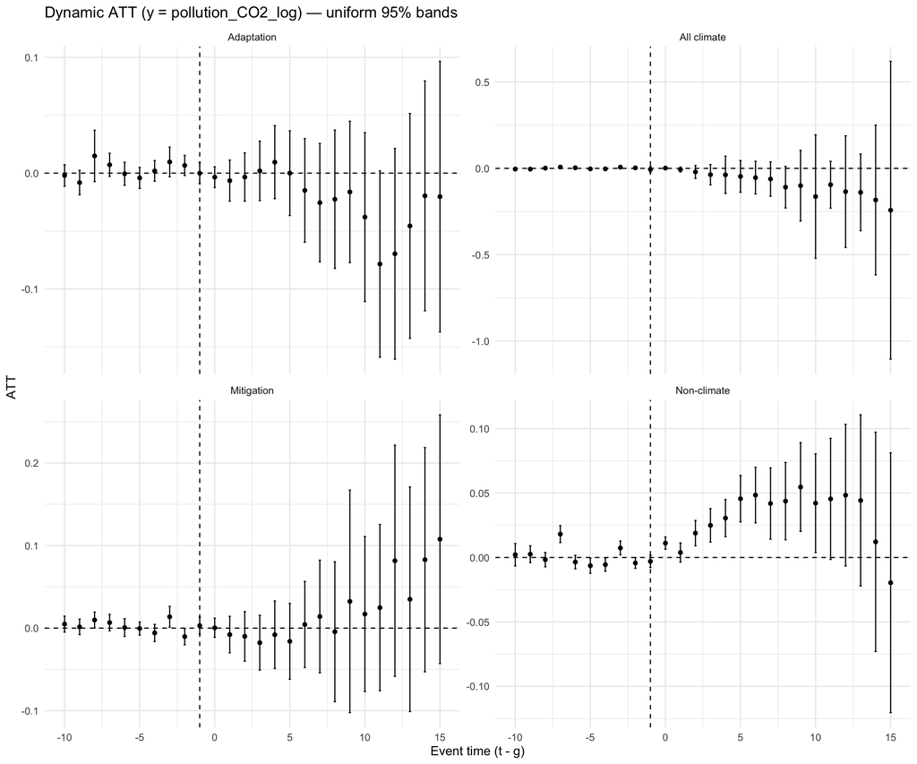

Figure 4: Dynamic treatment effects of aid adoption on local CO2 emissions (log). Event-time estimates (t−g) from Callaway–Sant’Anna DiD using not-yet-treated controls, doubly-robust estimator, and uniform 95% simultaneous bands (multiplier bootstrap; clustered at ADM2).

# 6 Heterogeneity

## 6.1 Event study by post-treatment dose bins

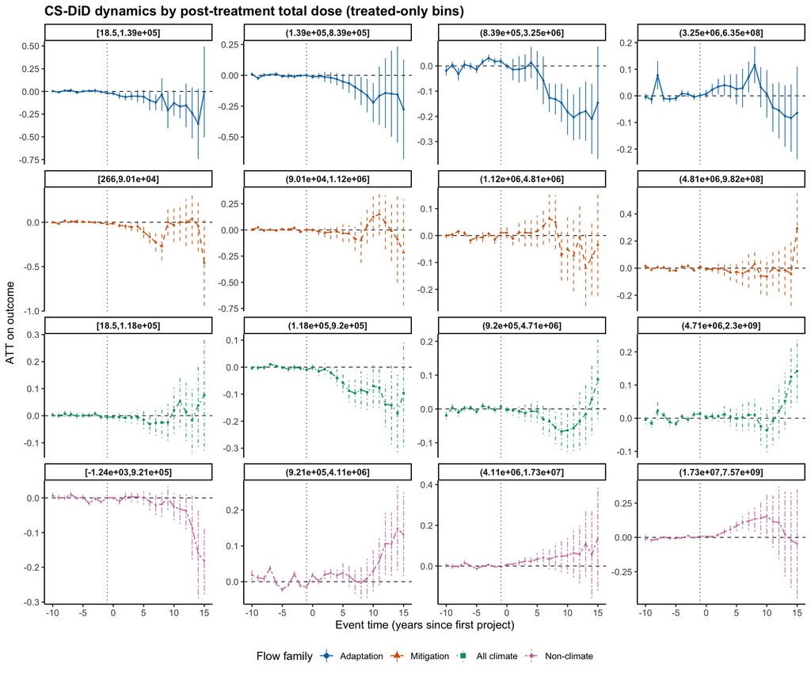

Figure 5: Event-study by post-treatment total dose — stratified bins (treated-only cuts).

## 6.2 Event-study per climate class

```
           class     g     N
          <char> <int> <int>
  1:         500  2001  1202
  2:         500  2002   773
  3:         500  2003   760
  4:         500  2004  1251
  5:         500  2005   984
 ---
224: Wind-energy  2013     5
225: Wind-energy  2016     5
226: Wind-energy  2017    14
227: Wind-energy  2019     5
228: Wind-energy  2020     7
```

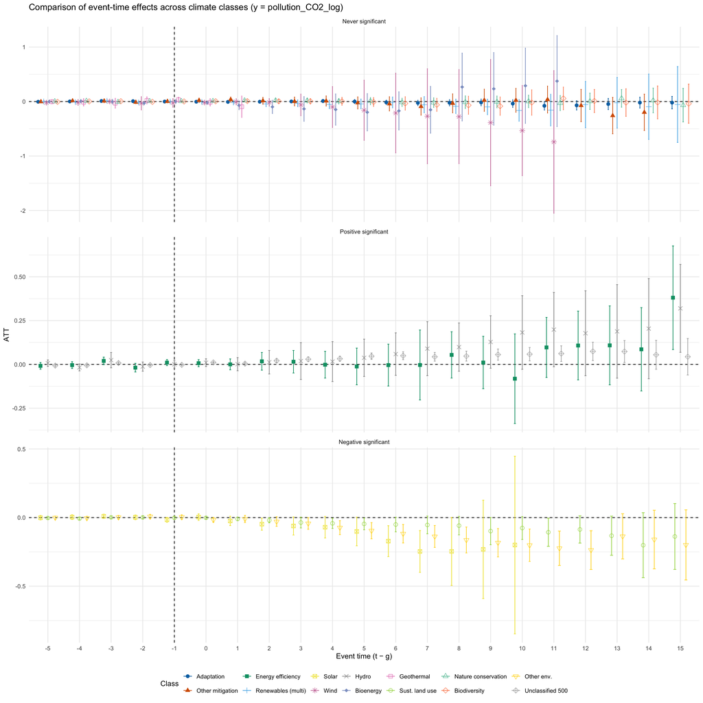

Comparison of event-time effects across climate classes

# 7 Robustness Checks

## 7.1 Placebo test

To probe identification, I implement a placebo event–study that advances the cohort year by four years $g^{pl}=g-4$ and re-estimates dynamic effects on the true pre-treatment sample. Results are displayed in Figure 6 . Across all four categories (Adaptation, Mitigation, All climate, Non-climate), placebo ATTs are close to zero around the pseudo-event time and the uniform 95% bands typically cover zero throughout the window, with no systematic departures. The mild drifts with widening intervals in far “post” leads are consistent with thinning support at long leads rather than genuine effects. Because any non-zero placebo effect would reflect differential pre-trends, these results provide no evidence of anticipatory dynamics or pre-trending, lending credibility to the parallel-trends condition underpinning our baseline estimates.

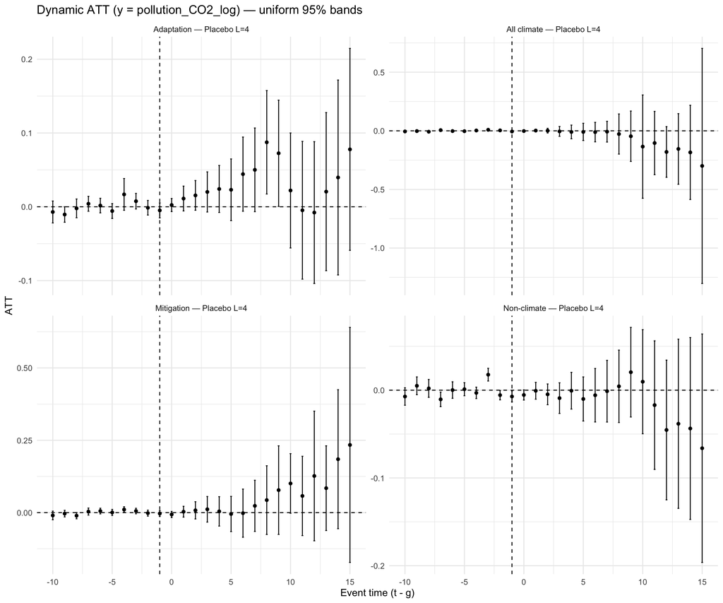

Figure 6: Dynamic treatment effects of aid adoption on local CO2 emissions (log). Event-time estimates (t−g) from Callaway–Sant’Anna DiD using not-yet-treated controls, doubly-robust estimator, and uniform 95% simultaneous bands (Placebo).

## 7.2 Excluding China

As one can see in Table 3, chinese adm2 region are overrepresented in top emission treated adm2. To assess the sensitivity of the results, I will exclude China from the regression to stress the results.

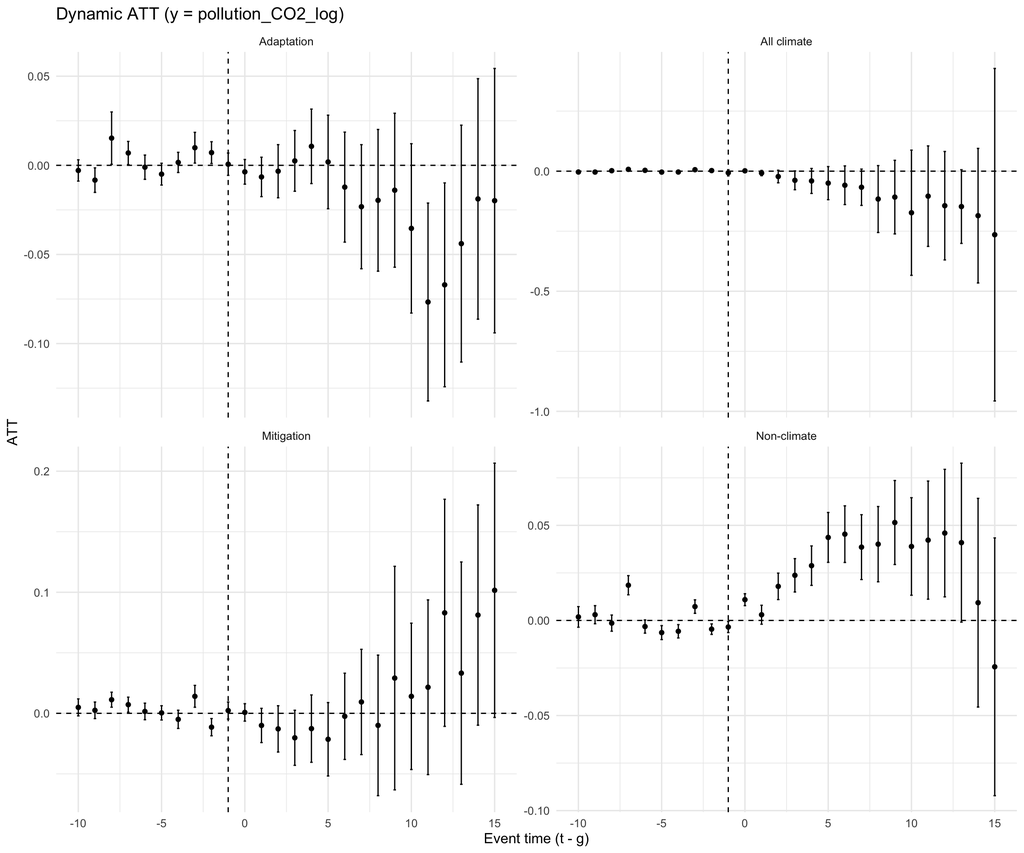

Figure 7: Dynamic treatment effects of aid adoption on local CO2 emissions (log, China excluded)

As we can see in Figure 7, removing chinese observations does not change the results. It even improves it if we look at adaptation aid, where one can see a significant drop in emission.

### 7.2.1 Intensity

As well for the intensity, the methodology is reproduced to stress the results in excluding chinese adm2 in Figure 8.

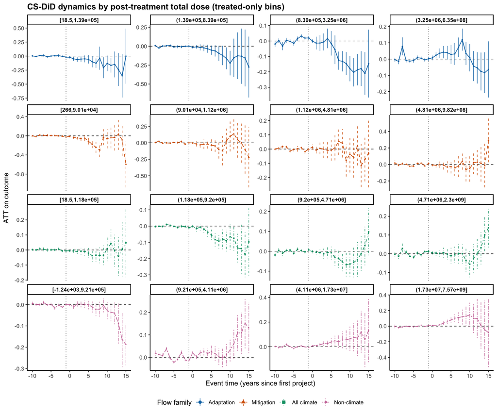

Figure 8: Event-study by post-treatment total dose — stratified bins (treated-only cuts, China excluded).

# 8 Mechanisms

To support the idea of non-climate related projects fostering development and therefore emission, I collected nighttime lights (NTL) yearly averaged at adm2 level in treated areas. I proxy local economic development with NTL for two reasons. First, a large literature shows that variation in NTL captures intensive-margin economic activity and infrastructure at fine spatial scales, especially where income data are sparse (J. V. Henderson, Storeygard, and Weil 2012; Chen and Nordhaus 2011; Pinkovskiy and Sala-i-Martin 2016). Second, NTL reacts contemporaneously to investments in roads, electrification, and urban services, giving a timely marker of development intensity at ADM2. The ex-ante hypothesis was therefore: non-climate aid (and some climate-related investments) should increase local development, captured by NTL, and, at least in the short run, also increase CO₂ emissions, via higher energy use, transport, construction, and operation of industrial/process activities.

1. LED/spectral-bias and dimming: Many projects retrofit public lighting and street infrastructure with LEDs or install smart dimming controls for energy efficiency. VIIRS-DNB is relatively less sensitive to blue-rich white LEDs and to reduced operating hours, so measured radiance can decline even when lumen output or activity does not (X. Li et al. 2017; Kyba et al. 2017; Levin et al. 2020). In parallel, improved connectivity and reliability can raise daytime activity, fuel use, and process/transport emissions, explaining a raise in CO2 with NTL near zero.
2. Daytime/process intensity with limited lighting: Industrial parks, cement and extractive activities, logistics hubs, and road programs primarily lift daytime or process loads (EDGAR industry/transport sectors) while adding little additional night lighting. This generates a high CO2 with little NTL response. Furthermore, in areas that are already highly illuminated, the likelihood of receiving large infrastructure investments (e.g., road construction) is greater. However, such projects can reduce observed night-time radiance when residential or commercial land uses, typically brighter at night, are replaced by transport infrastructure that emits less sustained light.

```
--- SAMPLE SIZE (obs = ADM2×year) ---
```

```
Original outcome (pollution_CO2_log): 878 669
```

```
VIIRS night-lights   : 566 592
```

```
Common keys: 382 020 | Only CO2: 496 649 | Only VIIRS: 184 572
```

```
Aligned dataset: 382 020 obs, 38202 ADM2
```

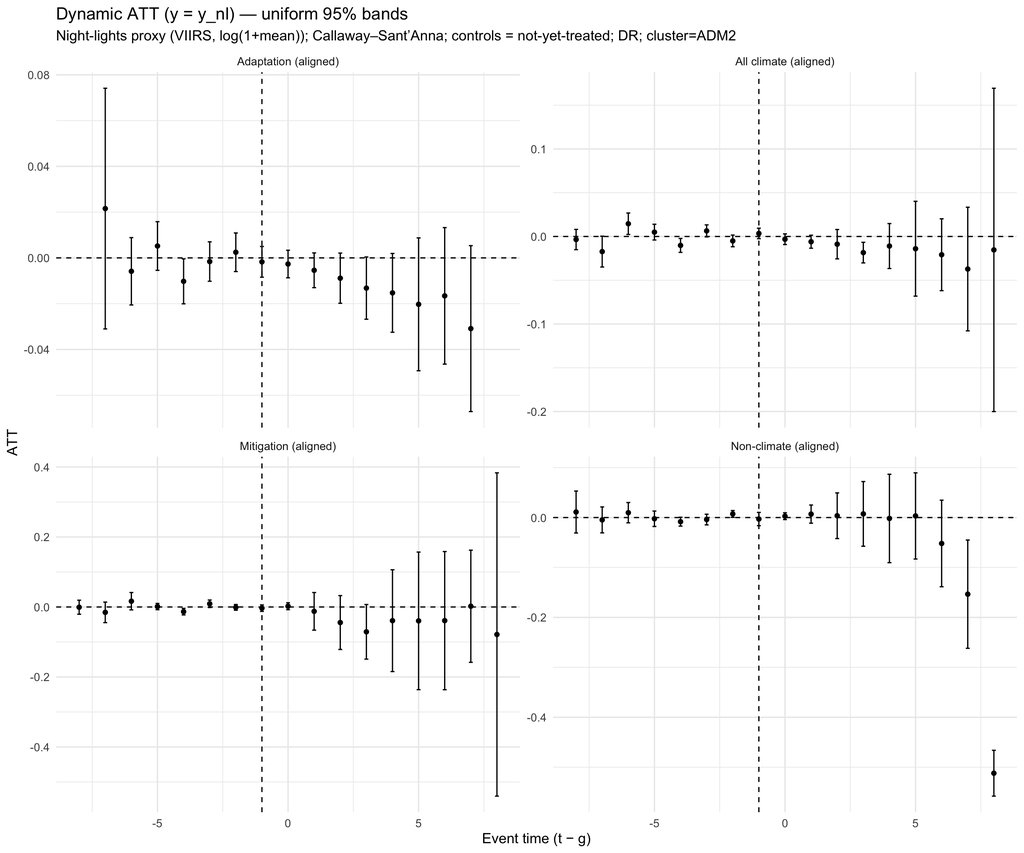

Figure 9: Dynamic treatment effects of aid adoption on NighTime Lights (log, ADM2)

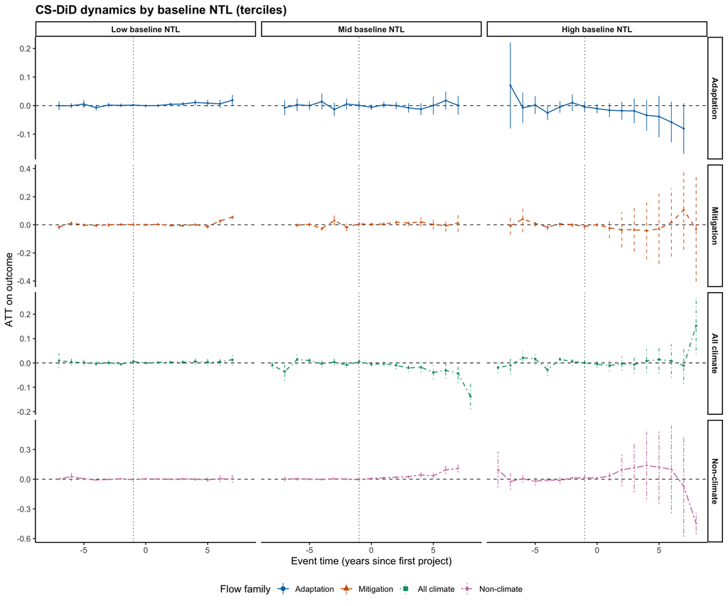

Figure 10: CS-DiD dynamics in night-time lights by baseline brightness (terciles)

Figure 10 directly speaks to mechanism (1): when we split the sample by baseline brightness terciles (2013), the post-t dimming is concentrated in the high-NTL tercile, precisely where public lighting stocks are largest and LED/dimming retrofits bite most. Pre-t coefficients remain near zero across terciles, reinforcing identification. Furthermore, in mid tercile of NTL at beginning of the observed period, one can see that non climate project are increasing NTL, whereas in high NTL, the lowering of NTL is coming at the end of the observable period and might be driven by high industrial and infrastructural projects. Figure 11 illustrates this.

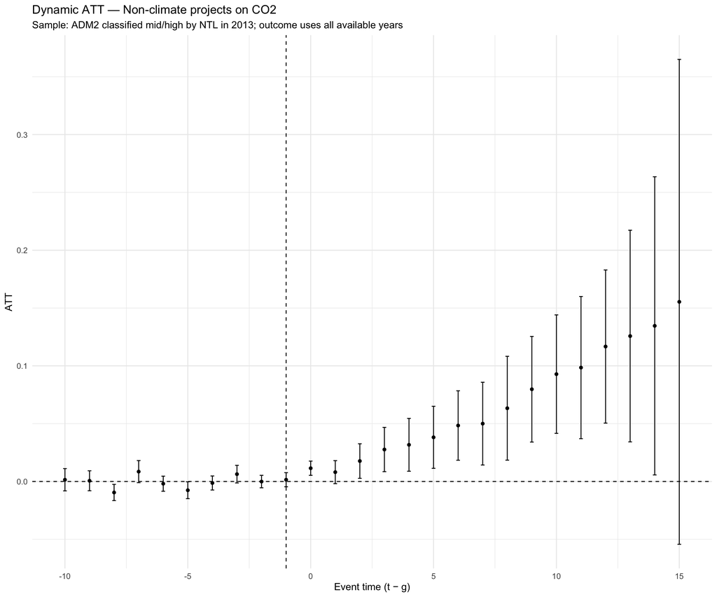

Figure 11: Dynamic ATT of non-climate projects on CO2 emissions (ADM2, mid/high NTL baseline)

Restricting the sample to ADM2 in the mid and high NTL terciles in the baseline year (2013) yields a clear post-treatment pattern for non-climate projects: CO2 emissions increase monotonically over the horizon, with flat pre-trends. Interpreting this together with our NTL results points to a development-driven mechanism in which non-climate assistance expands local economic activity, but the visibility of that expansion in night lights depends on baseline brightness and the composition of projects.

In mid-NTL areas, the project mix plausibly tilts toward development-oriented investments, housing upgrades, services, small commerce, electrification, that not only raise activity (and thus CO2) but also increase NTL, producing the expected positive association between development and measured radiance. By contrast, in already bright (high-NTL) areas, marginal brightening is harder to achieve (ceiling/saturation) and the portfolio shifts toward large transport and backbone infrastructure (roads, logistics platforms, rights-of-way). These investments scale daytime/process activity and emissions yet contribute little to sustained night radiance; they may even reduce NTL through land-use substitution (replacing brighter residential/commercial uses with less luminous transport surfaces) and through lighting efficiency changes (LED retrofits, dimming, shorter operating hours).

This mechanism reconciles the paper’s core findings. First, it explains why non-climate aid raises CO2 while NTL responses are muted or negative in bright places: NTL is sensitive to lighting technology and land-use composition, not just to output. Second, the heterogeneity by baseline brightness, NTL gains concentrated in mid-NTL ADM2 and attenuation in high-NTL ADM2, is consistent with selection into project types and with greater scope for efficiency retrofits where lighting stocks are large. Third, consistently flat pre-trends across specifications support the identifying assumptions of our DiD design.

Overall, the evidence indicates that non-climate assistance primarily scales up development-intensive, energy- and transport-using activity, while contemporaneous lighting and land-use changes modulate the NTL signal. This joint reading, CO₂2up, NTL up in mid-NTL; CO2 up, NTL flat/down in high-NTL, highlights the importance of combining NTL with sector-specific outcomes when assessing local development impacts.

## 8.1 Which climate aid tends to foster development ?

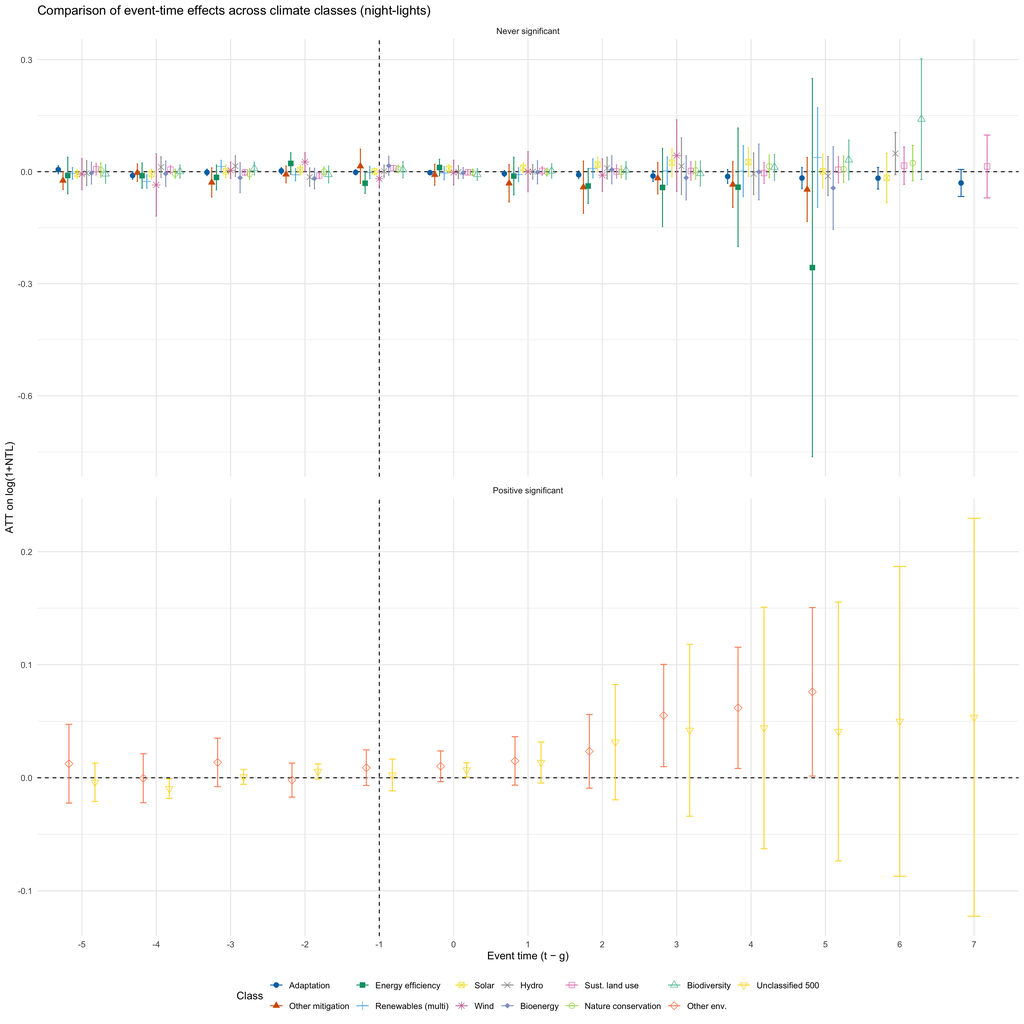

Event-study ATT on VIIRS night-lights (log(1+mean)) by GODAD climate classes. Facets group classes that show post-treatment uniform-significant positive, negative, or never-significant effects.

# 9 Policy Recommendations

```
Canon classes in NTL only:
```

```
Canon classes in CO2 only:
 Geothermal-energy
```

```
Canon classes used (intersection):
 Adaptation, Other-mitigation-projects, Energy-efficiency, Renewables-multiple, Solar-energy, Wind-energy, Hydro-energy, Bioenergy, Sustainable-land-use, Nature_conservation, Biodiversity, Other-environment-projects, 500
```

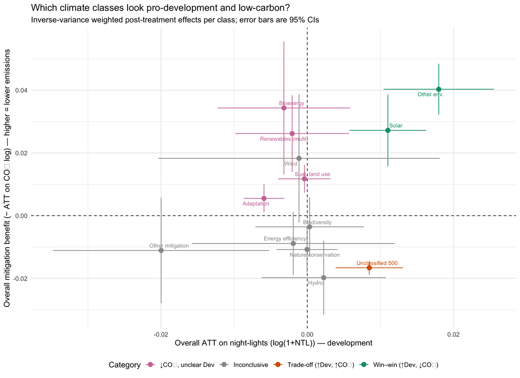

Development vs. GHG trade-offs by climate class. X: overall ATT on night-lights (log1p). Y: −ATT on CO₂ (log). Error bars are 95% CIs.

# 10 Conclusion

The mechanism is development-driven. Non-climate finance expands local economic activity, as reflected in night-time lights: NTL rises in mid-brightness ADM2 where additional commerce, services, and electrification are most visible; in high-brightness areas, NTL responses become muted or negative due to LED/dimming and land-use substitution toward transport/industrial infrastructure, even as CO2 rises through daytime/process loads. Thus “CO2 up” under non-climate aid is consistent with “development up,” with NTL mapping that expansion where radiance remains informative.

Policy follows directly. Scaling climate portfolios can deliver measurable local decarbonization (particularly where absorptive capacity makes dose–response steep), while greening or retargeting non-climate spending is necessary to avoid offsetting emissions from development-intensive sectors. NTL offers a practical monitoring proxy for development-induced emissions where spectral/land-use biases are accounted for.

Limitations include sectoral heterogeneity masked by averages and potential measurement error in climate tagging. Priority extensions are sector/technology decomposition, explicit spatial spillovers.

# References

Barkat, Karim, Mouyad Alsamara, and Karim Mimouni. 2024. “Beyond Economic Growth Goals: Can Foreign Aid Mitigate Carbon Dioxide Emissions in Developing Countries?” *Journal of Cleaner Production* 471 (September): 143411. https://doi.org/10.1016/j.jclepro.2024.143411.

Bomprezzi, P, A Dreher, A Fuchs, T Hailer, A Kammerlander, L Kaplan, S Marchesi, T Masi, and C Robert. 2024. “Wedded to Prosperity? Spousal Favoritism in Foreign Aid and Regional Development.” CEPR Discussion Paper 18878. Paris; London: Centre for Economic Policy Research (CEPR). https://cepr.org/publications/dp18878.

Callaway, Brantly, and Pedro H. C. Sant’Anna. 2021. “Difference-in-Differences with Multiple Time Periods.” *Journal of Econometrics* 225 (2): 200–230. https://doi.org/10.1016/j.jeconom.2020.12.001.

Chen, Xi, and Zhigang Chen. 2021. “Can Green Finance Development Reduce Carbon Emissions? Empirical Evidence from 30 Chinese Provinces.” *Sustainability* 13 (21): 12137. https://doi.org/10.3390/su132112137.

Chen, Xi, and William D. Nordhaus. 2011. “Using Luminosity Data as a Proxy for Economic Statistics.” *Proceedings of the National Academy of Sciences* 108 (21): 8589–94. https://doi.org/10.1073/pnas.1017031108.

Farooq, Umar. 2021. “Foreign Direct Investment, Foreign Aid, and CO2 Emissions in Asian Economies: Does Governance Matter?” *Environmental Science and Pollution Research* 29 (5): 7532–47. https://doi.org/10.1007/s11356-021-16115-3.

Henderson, J. Vernon, Adam Storeygard, and David N Weil. 2012. “Measuring Economic Growth from Outer Space.” *American Economic Review* 102 (2): 994–1028. https://doi.org/10.1257/aer.102.2.994.

Henderson, Kent E. 2019. “Contradictory Governance Norms Within World Society: Energy Development Strategies, Environmental Protection, and Carbon Dioxide Emissions.” *Environmental Sociology* 5 (4): 393–404. https://doi.org/10.1080/23251042.2019.1613031.

Henderson, Kent E., and Jamie Sommer. 2022. “Aiding Fossil Fuel Dependency: A Cross-National Analysis of Energy Sector Aid, National Autonomy, and CO2 Emissions in 122 Nations.” *International Journal of Sociology* 52 (1): 25–48. https://doi.org/10.1080/00207659.2021.2009273.

Kablan, Sandrine, and Valérie Chouard. 2022. “Does Climate Aid Matter for Reducing CO<sub>2</sub> Emissions? The Case of Foreign Aid for Renewable Energy.” *Applied Economics* 54 (46): 5357–72. https://doi.org/10.1080/00036846.2022.2044995.

Khan, Muhammad Asif, Masood Ahmed, and Rob Hull. 2023. “The Impact of Climate Mitigation Finance on Greenhouse Gas.” *Journal of Environmental Planning and Management* 67 (14): 3581–99. https://doi.org/10.1080/09640568.2023.2227759.

Kyba, Christopher C. M., Theres Kuester, Alejandro Sánchez de Miguel, Kimberly Baugh, Andreas Jechow, Franz Hölker, Jonathan Bennie, Christopher D. Elvidge, Kevin J. Gaston, and Luis Guanter. 2017. “Artificially Lit Surface of Earth at Night Increasing in Radiance and Extent.” *Science Advances* 3 (11). https://doi.org/10.1126/sciadv.1701528.

Lee, Chi-Chuan, Xinrui Li, Chin-Hsien Yu, and Jinsong Zhao. 2022. “The Contribution of Climate Finance Toward Environmental Sustainability: New Global Evidence.” *Energy Economics* 111 (July): 106072. https://doi.org/10.1016/j.eneco.2022.106072.

Lee, Sue Kyoung, Gayoung Choi, Eunmi Lee, and Taeyoung Jin. 2020. “The Impact of Official Development Assistance on the Economic Growth and Carbon Dioxide Mitigation for the Recipient Countries.” *Environmental Science and Pollution Research* 27 (33): 41776–86. https://doi.org/10.1007/s11356-020-10138-y.

Levin, Noam, Christopher C. M. Kyba, Qingling Zhang, Alejandro Sánchez de Miguel, Miguel O. Román, Xi Li, Boris A. Portnov, et al. 2020. “Remote Sensing of Night Lights: A Review and an Outlook for the Future.” *Remote Sensing of Environment* 237 (February): 111443. https://doi.org/10.1016/j.rse.2019.111443.

Li, Huiyun, Zongbao Yu, Gang Chen, and Yingjun Nie. 2025. “Research on the Impact of Green Finance on Regional Carbon Emission Reduction and Its Role Mechanisms.” *Scientific Reports* 15 (1). https://doi.org/10.1038/s41598-025-02481-2.

Li, Xi, Christopher Elvidge, Yuyu Zhou, Changyong Cao, and Timothy Warner. 2017. “Remote Sensing of Night-Time Light.” *International Journal of Remote Sensing* 38 (21): 5855–59. https://doi.org/10.1080/01431161.2017.1351784.

Mahalik, Mantu Kumar, Muhammed Ashiq Villanthenkodath, Hrushikesh Mallick, and Monika Gupta. 2021. “Assessing the Effectiveness of Total Foreign Aid and Foreign Energy Aid Inflows on Environmental Quality in India.” *Energy Policy* 149 (February): 112015. https://doi.org/10.1016/j.enpol.2020.112015.

Mumuni, Sulemana, and Yaya Deome Hamadjoda Lefe. 2023. “Greening the Environment: Do Climate-Related Development Finances and Renewable Energy Consumption Matter? An African Tale.” *Carbon Management* 14 (1). https://doi.org/10.1080/17583004.2023.2251934.

Pinkovskiy, Maxim, and Xavier Sala-i-Martin. 2016. “Lights, Camera … Income! Illuminating the National Accounts-Household Surveys Debate *.” *The Quarterly Journal of Economics* 131 (2): 579–631. https://doi.org/10.1093/qje/qjw003.

Sadiq, Muhammad, Ka Yin Chau, Nguyen Tran Thai Ha, Thi Thu Hien Phan, Thanh Quang Ngo, and Pham Quang Huy. 2024. “The Impact of Green Finance, Eco-Innovation, Renewable Energy and Carbon Taxes on CO2 Emissions in BRICS Countries: Evidence from CS ARDL Estimation.” *Geoscience Frontiers* 15 (4): 101689. https://doi.org/10.1016/j.gsf.2023.101689.

Saeed Meo, Muhammad, and Mohd Zaini Abd Karim. 2022. “The Role of Green Finance in Reducing CO2 Emissions: An Empirical Analysis.” *Borsa Istanbul Review* 22 (1): 169–78. https://doi.org/10.1016/j.bir.2021.03.002.

Sharif, Arshian, Najia Saqib, Kangyin Dong, and Syed Abdul Rehman Khan. 2022. “Nexus Between Green Technology Innovation, Green Financing, and CO<sub>2</sub> Emissions in the G7 Countries: The Moderating Role of Social Globalisation.” *Sustainable Development* 30 (6): 1934–46. https://doi.org/10.1002/sd.2360.

Su, Xiao, Ruiyun Qiao, and Shengyan Xu. 2024. “Impact of Green Finance on Carbon Emissions and Spatial Spillover Effects: Empirical Evidence from China.” *Journal of Cleaner Production* 457 (June): 142362. https://doi.org/10.1016/j.jclepro.2024.142362.

Sun, Jing, Ningning Zhai, Jichao Miao, and Huaping Sun. 2022. “Can Green Finance Effectively Promote the Carbon Emission Reduction in “Local-Neighborhood” Areas?Empirical Evidence from China.” *Agriculture* 12 (10): 1550. https://doi.org/10.3390/agriculture12101550.

Sun, Yunpeng, Qun Bao, and Farhad Taghizadeh-Hesary. 2023. “Green Finance, Renewable Energy Development, and Climate Change: Evidence from Regions of China.” *Humanities and Social Sciences Communications* 10 (1). https://doi.org/10.1057/s41599-023-01595-0.

Toetzke, Malte, Anna Stünzi, and Florian Egli. 2022. “Consistent and Replicable Estimation of Bilateral Climate Finance.” *Nature Climate Change* 12 (10): 897–900.

Umar, Muhammad, and Adnan Safi. 2023. “Do Green Finance and Innovation Matter for Environmental Protection? A Case of OECD Economies.” *Energy Economics* 119 (March): 106560. https://doi.org/10.1016/j.eneco.2023.106560.

Wang, Fushuai, Wenxia Cai, and Ehsan Elahi. 2021. “Do Green Finance and Environmental Regulation Play a Crucial Role in the Reduction of CO2 Emissions? An Empirical Analysis of 126 Chinese Cities.” *Sustainability* 13 (23): 13014. https://doi.org/10.3390/su132313014.

Wang, Leiling, Xiaoyun Yang, and Qihua Cai. 2024. “Influence Mechanism of Green Finance on Regional Emission Reduction.” *Heliyon* 10 (1): e23861. https://doi.org/10.1016/j.heliyon.2023.e23861.

Zhao, Xin, Ramzi Benkraiem, Mohammad Zoynul Abedin, and Silu Zhou. 2024. “The Charm of Green Finance: Can Green Finance Reduce Corporate Carbon Emissions?” *Energy Economics* 134 (June): 107574. https://doi.org/10.1016/j.eneco.2024.107574.

# Appendix

Table 3: Top 20 ADM2 by mean CO$_2$ level (EDGAR-aggregated).

Top 20 ADM2 by mean CO$_2$ level (EDGAR-aggregated).

| Rank | Country | ADM2 ID | Mean CO2 |
| --- | --- | --- | --- |
| 1 | China | CHN.10.9_1 | 199 632 759 |
| 2 | China | CHN.24.1_1 | 141 872 754 |
| 3 | China | CHN.15.7_1 | 133 343 969 |
| 4 | China | CHN.3.1_1 | 120 020 252 |
| 5 | South Africa | ZAF.6.3_1 | 115 805 012 |
| 6 | China | CHN.15.10_1 | 113 811 236 |
| 7 | China | CHN.23.13_1 | 104 862 150 |
| 8 | China | CHN.27.1_1 | 103 411 029 |
| 9 | China | CHN.10.4_1 | 99 511 528 |
| 10 | China | CHN.23.17_1 | 98 720 889 |
| 11 | China | CHN.19.7_1 | 96 086 514 |
| 12 | China | CHN.15.4_1 | 87 744 994 |
| 13 | China | CHN.23.16_1 | 83 558 272 |
| 14 | China | CHN.12.16_1 | 78 899 516 |
| 15 | China | CHN.28.5_1 | 76 522 584 |
| 16 | China | CHN.23.9_1 | 74 562 077 |
| 17 | China | CHN.13.12_1 | 72 518 799 |
| 18 | China | CHN.18.1_1 | 72 069 729 |
| 19 | China | CHN.13.4_1 | 70 898 769 |
| 20 | China | CHN.10.8_1 | 70 602 072 |

Note:  
CO2 levels are ADM2 means over the panel. Units follow the EDGAR source used for aggregation. Countries are matched from ISO3 codes; unmatched codes remain as ISO3.

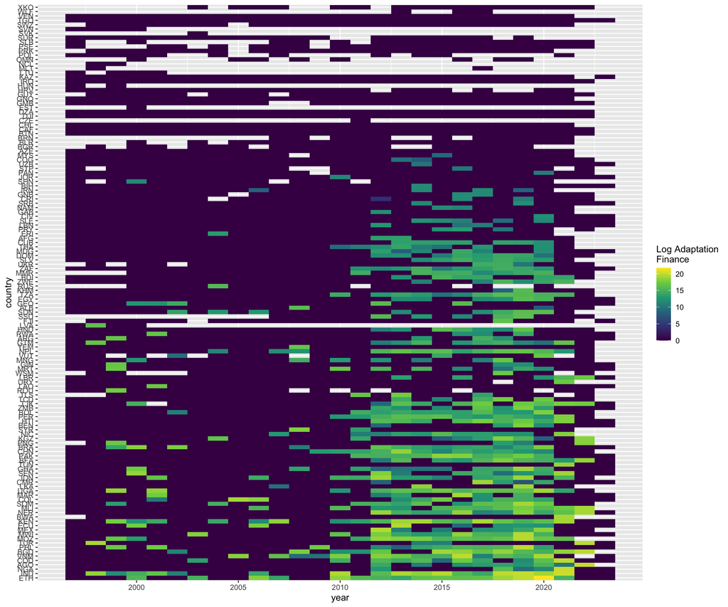

Heatmaps of Adaptation Finance per Country

[figure not shown]

Adaptation bins post treatment intensity repartition

## Footnotes

[^1]: Preliminary version, please do not transfer, cite or use. This work was supported by the Agence Nationale de la Recherche of the French government through the program "Investissements d’avenir, ANR-10-LABX-14-01".
[^2]: Preliminary version, please do not transfer, cite or use. This work was supported by the Agence Nationale de la Recherche of the French government through the program "Investissements d’avenir, ANR-10-LABX-14-01".
[^3]: Preliminary version, please do not transfer, cite or use. This work was supported by the Agence Nationale de la Recherche of the French government through the program "Investissements d’avenir, ANR-10-LABX-14-01".